### This program allows rapid assessment of a variety of machine learning algorithms to evaluate a

- Classification model in which a binary outcome (0/1, TRUE/FALSE, toxic/non-toxic) is being predicted
- Regression model in which a number is being predicted

#### This is a R Markdown program.

#### RStudio is recommended to run the program, either in chunks or all at once. To run all chunks automatically, use the Knit option in RStudio.

#### With the exception of what you are trying to predict, all data must be an integer or numeric data type. Factor variables in the dataset are automatically deleted. The next iteration of this program will allow additional factor variables.

Date: 14 November 2018 Author: Neal Cariello  
Senior Toxicologist  
Integrated Laboratory Systems, Research Triangle Park, NC

Supporting:  
NTP Interagency Center for the Evaluation of Alternative Toxicological Methods (NICEATM)  
https://www.niehs.nih.gov/research/atniehs/dntp/assoc/niceatm/index.cfm

email: cariello@niehs.nih.gov, ncariello@ils-inc.com, neal.f.cariello@gmail.com

Multiple machine learning algorithms can be used to easily evaluate different models sequentially using the syntax:  
MLmethods <- c(‘rf’, ‘svmRadial’, ‘xgbLinear’, etc)

R Markdown is used so all code and output is in a single HTML file.

The workflow uses the R package caret which greatly simplifies coding and presents a unified interface for 238 machine learning algorithms. The caret package varies tuning parameters when appropriate for a given machine learning method.

The main caret page is at http://topepo.github.io/caret/index.html

The default is to scale the data to mean 0 and standard deviation 1. This is also called a Z-Score transformation. Scaling is done in the function ModelFit(). Different data transformations are available.

My recommendation is to:

- Scale the input data assuming the variables have different ranges.
  - Not doing so will favor the variables with the highest values. For example, the house price will greatly influence the model since it has a much higher range than the number of bedrooms:
    - House price in thousands (range 100 - 1000)
    - Number of bedrooms (range 1 - 6)
  - A variable with an arbitrary scale should always be normalized
    - For example, the house price can be expressed as thousands of dollars or dollars (1,000 vs 1,000,000).

Analyzing data with missing values can be problematical and the default is to:

- Remove all rows with >10% missing values THEN
- Remove all columns with >10% missing values
- Impute missing values using the k-Nearest Neighbor method in the DMwR package
- The percent missing values can set set by the user

The program defaults to:

- Remove highly-correlated variables
  - It is important to removed highly-correlated variables since they may be reporting on the same features and not removing them may lead to over-optimistic performance metrics.
- Remove variables with near-zero variance
  - Features with near-zero variance contribute little to the model and will increase compute time

See the accompaning Word document for more program information,

This is a R Markdown program. Individual chunks can be executed or the entire program can be  
run using the Knit option in RStudio.

This code was run on Windows 7 and 10 using R 3.5.1

## User defined variables and conditions to run program

```
## [1] "Windows configuation"
```

```
## Path to store the R environment is:
##  C:/Google Drive/R/caret/Generic Caret Workflow/00_release/niceatm-machine-learning-pipeline/for_fitted_models/
```

## Functions

```
## [1] "Using regression model"
```

## Load Data, Inspect Distribution, Check For NA’s And Perform Optional Imputation

```
## [1] "Returning default dataset for regression"
## [1] "BostonHousing data in mlbench package is being used"
## [1] "An extra factor column is added to test that dropping extra factor columns works OK"
```

```
## [1] "This program requires that all data other than ***toPredict*** be numeric.  Removing factor columns: "
## [1] "newCol"
```

```
## [1] "Dataframe dimensions after imputation:"
```

```
## [1] 506  14
```

```
## [1] "Variable names:"
```

```
##  [1] "toPredict" "crim"      "zn"        "indus"     "chas"
##  [6] "nox"       "rm"        "age"       "dis"       "rad"
## [11] "tax"       "ptratio"   "b"         "lstat"
```

```
## [1] "All data should be integer or numeric"
```

```
## [1] "Data types"
```

```
##
## numeric
##      14
```

```
## [1] "Dataframe structure:"
```

```
## 'data.frame':    506 obs. of  14 variables:
##  $ toPredict: num  24 21.6 34.7 33.4 36.2 28.7 22.9 27.1 16.5 18.9 ...
##  $ crim     : num  0.00632 0.02731 0.02729 0.03237 0.06905 ...
##  $ zn       : num  18 0 0 0 0 0 12.5 12.5 12.5 12.5 ...
##  $ indus    : num  2.31 7.07 7.07 2.18 2.18 2.18 7.87 7.87 7.87 7.87 ...
##  $ chas     : num  1 1 1 1 1 1 1 1 1 1 ...
##  $ nox      : num  0.538 0.469 0.469 0.458 0.458 0.458 0.524 0.524 0.524 0.524 ...
##  $ rm       : num  6.58 6.42 7.18 7 7.15 ...
##  $ age      : num  65.2 78.9 61.1 45.8 54.2 58.7 66.6 96.1 100 85.9 ...
##  $ dis      : num  4.09 4.97 4.97 6.06 6.06 ...
##  $ rad      : num  1 2 2 3 3 3 5 5 5 5 ...
##  $ tax      : num  296 242 242 222 222 222 311 311 311 311 ...
##  $ ptratio  : num  15.3 17.8 17.8 18.7 18.7 18.7 15.2 15.2 15.2 15.2 ...
##  $ b        : num  397 397 393 395 397 ...
##  $ lstat    : num  4.98 9.14 4.03 2.94 5.33 ...
```

```
##    toPredict          crim                zn             indus
##  Min.   : 5.00   Min.   : 0.00632   Min.   :  0.00   Min.   : 0.46
##  1st Qu.:17.02   1st Qu.: 0.08204   1st Qu.:  0.00   1st Qu.: 5.19
##  Median :21.20   Median : 0.25651   Median :  0.00   Median : 9.69
##  Mean   :22.53   Mean   : 3.61352   Mean   : 11.36   Mean   :11.14
##  3rd Qu.:25.00   3rd Qu.: 3.67708   3rd Qu.: 12.50   3rd Qu.:18.10
##  Max.   :50.00   Max.   :88.97620   Max.   :100.00   Max.   :27.74
##       chas            nox               rm             age
##  Min.   :1.000   Min.   :0.3850   Min.   :3.561   Min.   :  2.90
##  1st Qu.:1.000   1st Qu.:0.4490   1st Qu.:5.886   1st Qu.: 45.02
##  Median :1.000   Median :0.5380   Median :6.208   Median : 77.50
##  Mean   :1.069   Mean   :0.5547   Mean   :6.285   Mean   : 68.57
##  3rd Qu.:1.000   3rd Qu.:0.6240   3rd Qu.:6.623   3rd Qu.: 94.08
##  Max.   :2.000   Max.   :0.8710   Max.   :8.780   Max.   :100.00
##       dis              rad              tax           ptratio
##  Min.   : 1.130   Min.   : 1.000   Min.   :187.0   Min.   :12.60
##  1st Qu.: 2.100   1st Qu.: 4.000   1st Qu.:279.0   1st Qu.:17.40
##  Median : 3.207   Median : 5.000   Median :330.0   Median :19.05
##  Mean   : 3.795   Mean   : 9.549   Mean   :408.2   Mean   :18.46
##  3rd Qu.: 5.188   3rd Qu.:24.000   3rd Qu.:666.0   3rd Qu.:20.20
##  Max.   :12.127   Max.   :24.000   Max.   :711.0   Max.   :22.00
##        b              lstat
##  Min.   :  0.32   Min.   : 1.73
##  1st Qu.:375.38   1st Qu.: 6.95
##  Median :391.44   Median :11.36
##  Mean   :356.67   Mean   :12.65
##  3rd Qu.:396.23   3rd Qu.:16.95
##  Max.   :396.90   Max.   :37.97
```

```
## Using  as id variables
```

```
##    variable value
## 1 toPredict  24.0
## 2 toPredict  21.6
## 3 toPredict  34.7
## 4 toPredict  33.4
## 5 toPredict  36.2
## 6 toPredict  28.7
```

```
## Variable plots may be unreadable in the HTML output, the recommendation is to enlarge the R plot window
##     and take a screen shot of this.
```

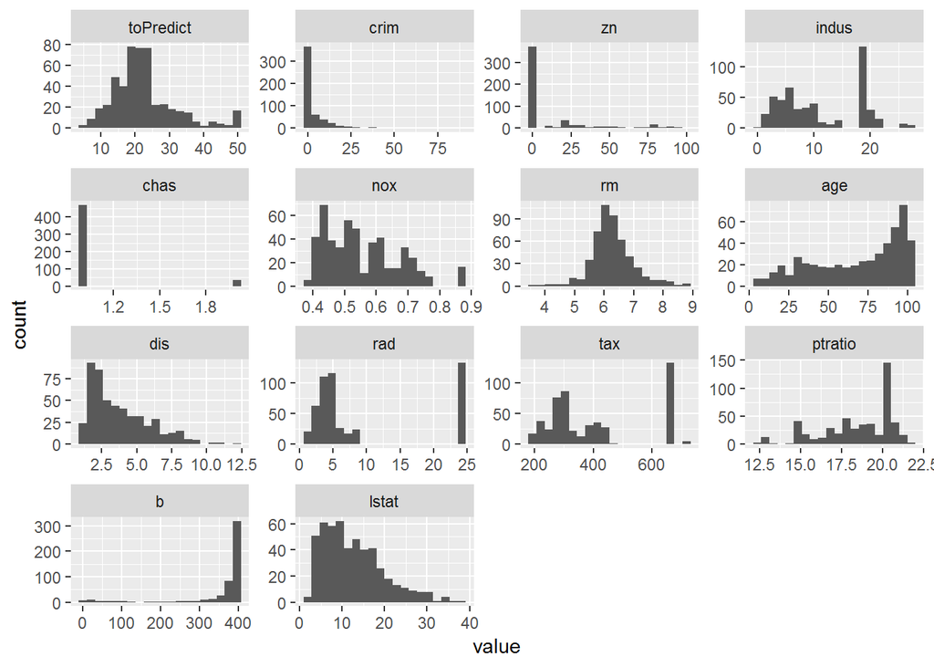

```
## [1] "Number of workers: 3"
## [1] "Returns TRUE if doPar backend is registed: TRUE"
## [1] "Name : doParallelSNOW"
## [1] "Version: 1.0.11"
## [1] "Cores: 4"
## Totalram:  31.910 GiB
## Freeram:   22.069 GiB
## [1] "Parallel processing enabled"
```

## Determine features for possible exclusion: near zero variance

```
## [1] "Variables with near zero variance will be removed"
## [1] There are no columns with near zero variance
```

## Highly Correlated Variables (Also Called Features) For Possible Exclusion

```
## The plot may be unreadable in the HTML output, the recommendation is to enlarge the R plot window
##     and take a screen shot of this.
```

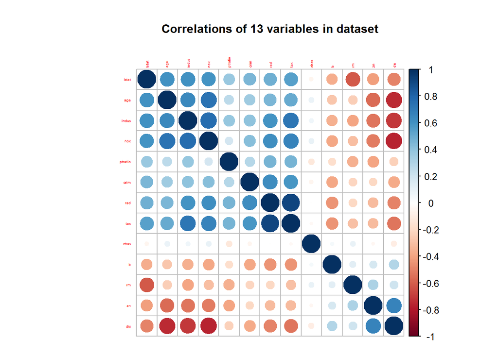

```
## [1] "No highly correlated variables found"
```

### PCA and t-SNE data visualization performed only for classification model

## Create training and test datasets. Check class imbalance.

### caret has some simple methods for correcting class imbalance, see caret::downSample and caret:: upSample

```
## [1] 381  14
```

```
## [1] 125  14
```

## Print runtime options, Run Models and Save R Environment To Disk

See Max Kuhn’s caret website about picking models that are very different from one another (orthogonal).  
http://topepo.github.io/caret/models-clustered-by-tag-similarity.html

```
## [1] "Final data dimensions"
```

```
## [1] 506  14
```

```
## [1] "USER SETTINGS ARE:"
```

```
## Date:  2018_11_14
```

```
## Model type:  REGRESSION
```

```
## Machine Learning Methods:  rf knn svmRadial
```

```
## Parallel computing:  TRUE
```

```
## Remove highly-correlated variables:  TRUE
```

```
## Remove low variance variable:  TRUE
```

```
## Use default datasets for testing program:  TRUE
```

```
## Visualization for categorical data:  TRUE
```

```
## Add NAs:  FALSE
```

```
## [1] "ML methods used: rf"        "ML methods used: knn"
## [3] "ML methods used: svmRadial"
```

```
## [1] Starting rf at 2018-11-14 15:44:10
## [1] "Time to run rf"
## Time difference of 43.41734 secs
## [1] rfFit created
## [1] "-------------------------------------------"
## [1] Starting knn at 2018-11-14 15:44:53
## [1] "Time to run knn"
## Time difference of 0.9300931 secs
## [1] knnFit created
## [1] "-------------------------------------------"
## [1] Starting svmRadial at 2018-11-14 15:44:54
## [1] "Time to run svmRadial"
## Time difference of 2.612261 secs
## [1] svmRadialFit created
## [1] "-------------------------------------------"
```

```
## [1] "Overall time to run models 3 models:"
```

```
## Time difference of 46.9757 secs
```

## Variable Importance And Tuning Parameters

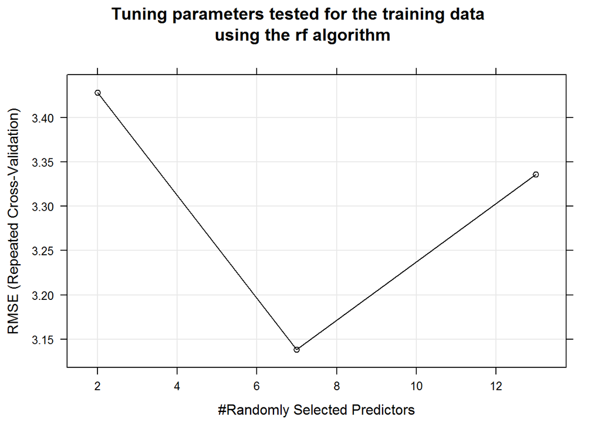

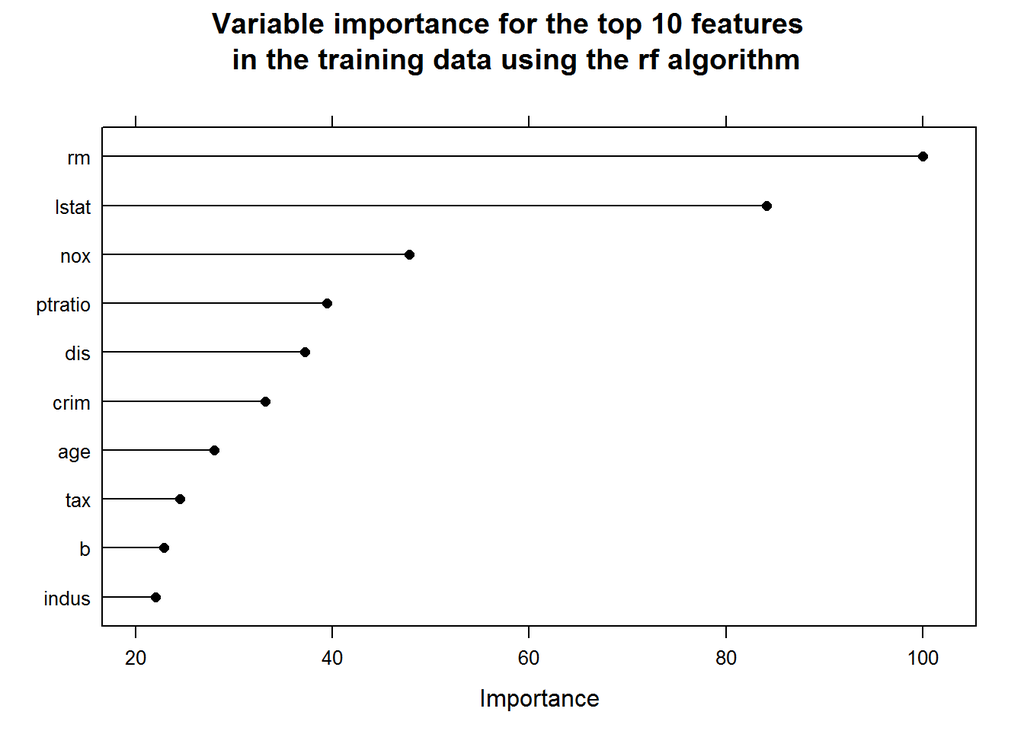

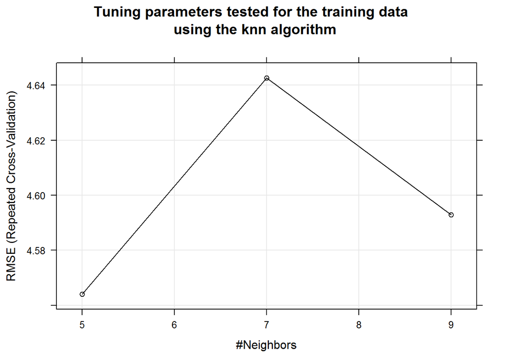

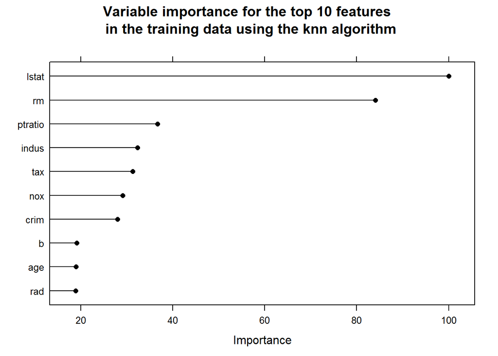

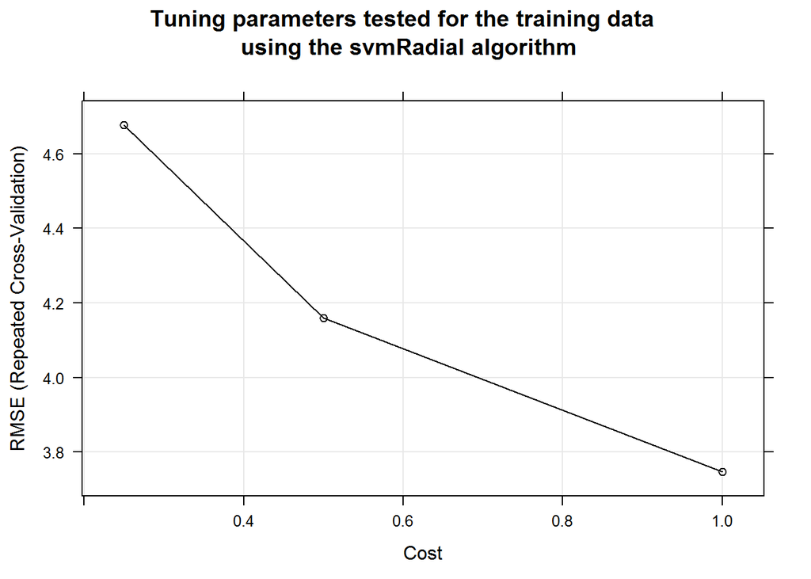

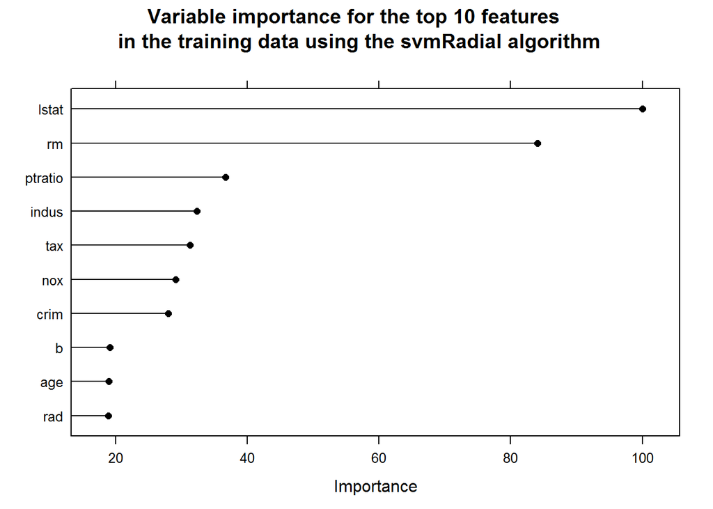

**For the CLASSIFICATION MODEL, the Receiver Operating Characteristic (ROC), Sensitivity (Sens) and Specificity (Spec) for the TRAINING data are plotted here.**

**For the REGRESSION MODEL, Mean Average Error (MAE), Root Mean Squared Error (RMSE) and Pearson R-Squared for the TRAINING data are plotted here.**

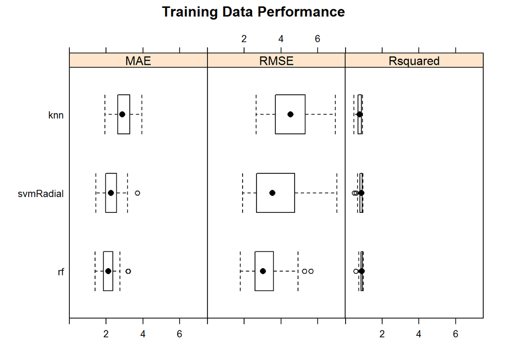

```
##
## Call:
## summary.diff.resamples(object = diffsModels)
##
## p-value adjustment: bonferroni
## Upper diagonal: estimates of the difference
## Lower diagonal: p-value for H0: difference = 0
##
## MAE
##           rf        knn       svmRadial
## rf                  -0.8254   -0.1762
## knn       1.001e-11            0.6492
## svmRadial 0.1973    6.183e-10
##
## RMSE
##           rf        knn     svmRadial
## rf                  -1.4256 -0.6091
## knn       7.142e-08          0.8165
## svmRadial 0.02188   0.00237
##
## Rsquared
##           rf       knn      svmRadial
## rf                  0.11185  0.05117
## knn       3.59e-07          -0.06067
## svmRadial 0.03316  0.03090
```

**Performance on TESTING DATA for Classification model: Confusion Matrix, Sensitivity, Specificity, Accuracy, Kappa Statistic and more are given here.**

**Performance on TESTING DATA for Regression model: Mean Average Error (MAE), Root Mean Squared Error (RMSE) and R-Squared are plotted here.**

```
## Data in the toPredict column has a range of 5 50
## [1] The range is important in interpreting the RMSE, which is in the same units as toPredict
## [1] The smaller the RMSE, the better the model
##
##  Performance metrics for the testing data using model rf
##      RMSE  Rsquared       MAE
## 3.7131522 0.8819336 2.5367148
##
##  Performance metrics for the testing data using model knn
##      RMSE  Rsquared       MAE
## 4.6560186 0.7976201 2.9936000
##
##  Performance metrics for the testing data using model svmRadial
##      RMSE  Rsquared       MAE
## 4.4134791 0.8126368 2.6780505
```

## Stop Parallel Processing And Return To Single Thread Processing

```
## [1] "Single thread processing re-enabled"
```

```
## [1] "Time to run entire program"
```

```
## Time difference of 55.20052 secs
```